# **La percepción de los estudiantes de UTEC matriculados en el ciclo 2023-1 respecto a la seguridad en el traslado Domicilio - Campus UTEC**

Grupo 3 - Laboratorio 5

30 Agosto, 2023

# **Introducción**

Nuestro proyecto busca estudiar la percepción de los estudiantes de la Universidad de Ingeniería y Tecnología (UTEC) respecto al nivel de seguridad en el desplazo desde su domicilio hasta el campus de UTEC y viceversa.

## **Contexto**

El traslado a la universidad es un hecho continuo para todos los estudiantes. Desde que se acabó la modalidad virtual, los estudiantes se han visto obligados a exponerse de nuevo a la inseguridad de las calles. Bajo este contexto, se busca determinar qué tan inseguro es realmente el traslado diario para un estudiante. Nuestro grupo, conformado por estudiantes universitarios, quiere visualizar el panorama de la inseguridad por medio de análisis de datos, obteniendo la verdadera cara del traslado, o al menos, acercarnos un poco. Todo este análisis servirá para que en caso hayan problemas de inseguridad en el traslado, se puedan tener etiquetadas las causas más problemáticas y tomar las medidas correspondientes a cada una.

Entonces, para nuestra investigación se debe tener lo siguiente en cuenta:

- **Diferencias entre los estudiantes:** Dentro de nuestra lista tenemos que hacer una diferenciación entre los agentes encuestados, puesto que cada uno presenta propiedades diferentes; propiedades que afectan dentro del análisis de datos.Como las diferencias entre rutas de cada estudiante, tiempo que les toma llegar a la universidad, sistemas vehiculares a usar durante su transporte, nivel de seguridad o importancia moral y económica de las cosas robadas.
- **Factores vinculados al nivel de riesgo:** Se puede explicar como factores ajenos a las decisiones del estudiante. Por ejemplo, la ubicación de la universidad o el nivel de riesgo de cada método de transporte.
- **Aporte de la universidad:** Se relaciona a las acciones que toma la universidad para aportar a la seguridad del estudiante.

## **Planificación**

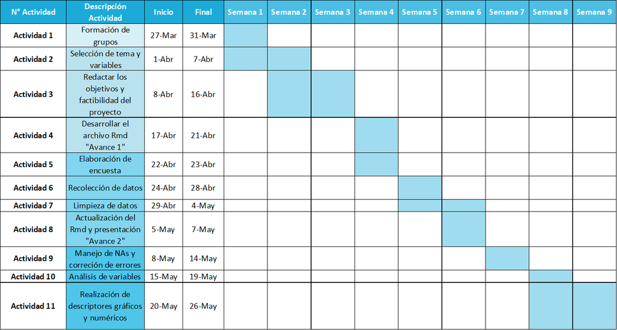

## **Relevancia**

Este trabajo de investigación es relevante para describir el panorama actual que viven los estudiantes de UTEC concernientes a la seguridad durante el transporte. Es así como determinar la percepción de seguridad en un estudiante que se traslada continuamente a la universidad y cuál es el nivel de riesgo al que se pueden llegar a exponer, para así en base a la información obtenida existan propuestas que contribuyan a mejorar la experiencia universitaria respecto al transporte.

## **Objetivo general**

- Describir el panorama de seguridad durante el traslado Domicilio-UTEC en estudiantes de la Universidad de Ingeniería y Tecnología (UTEC) matriculados en el 2023-1.

## **Objetivos específicos**

- Determinar qué tan inseguro es el traslado a la universidad en estudiantes de UTEC actualmente matriculados.
- Identificar los factores personales que afectan al nivel de seguridad de los estudiantes UTEC actualmente matriculados durante el traslado.
- Determinar qué medios de transporte son los más riesgosos al momento de desplazarse para los estudiantes de UTEC matriculados en el 2023-1.
- Determinar la parte del día en la que es más riesgoso trasladarse para un estudiante UTEC actualmente matriculado.
- Observar patrones específicos en la experiencia de traslado dictados por variables demográficas como edad y ciclo en estudiantes UTEC actualmente matriculados.
- Contribuir con una retroalimentación acerca de cómo UTEC puede contribuir en la mejora de la percepción de seguridad de los estudiantes de UTEC actualmente matriculados.

# **Datos**

## **Herramienta de recolección de datos**

[Encuesta: La percepción de los estudiantes de UTEC matriculados en el ciclo 2023-1 respecto a la seguridad en el traslado Domicilio - Campus UTEC](https://forms.gle/NokCWu7QBkT4UkUG9)

**¿Cómo se obtuvieron los datos?**

**¿Por qué se hizo la recolección de datos de esa manera?**

- Porque es una manera más versátil de llegar a todos los alumnos y en cuanto a la herramienta escogida, esta permite que los datos obtenidos sean mejor manejados porque nos da la posibilidad de descargar directamente la data en formato **.csv**, listo para trabajarlo en RStudio.

**¿Cuáles fueron las condiciones para realizar la recolección?**

- La única condición que tuvimos al momento de la recolección fue que el individuo estudie actualmente en UTEC.

**¿Qué estrategias consideramos para llegar a la población?**

- Compartimos las encuestas con amigos cercanos y grupos de estudios UTEC.
- La publicación del link del cuestionario en nuestras redes sociales.
- Para evitar participación externa restringimos el acceso para que solo la pueda responder la comunidad UTEC.
- En forma de de recompensa regalamos dulces por llenar nuestras encuestas.

## **Población**

Nuestra población será los estudiantes que se trasladan hacia la Universidad de Ingeniería y Tecnología (UTEC).

**Unidad Muestral**

- La unidad muestral es cada estudiante de las distintas provincias de Lima :

| . | . | . |
| --- | --- | --- |
| Ate Vitarte | Barranco | Carabayllo |
| Chaclacayo | Chorrillos | Cieneguilla |
| Comas | El Agustino | Independencia |
| Jesús María | La Molina | La Victoria |
| Lima | Lince | Los Olivos |
| Lurín | Magdalena del Mar | Miraflores |
| Pachacamac | Pueblo Libre | Puente Piedra |
| Punta Hermosa | Rímac | San Borja |
| San Juan De Miraflores | San Juan Del Lurigancho | San Luis |
| San Martin De Porres | San Miguel | Santa Anita |
| Santiago De Surco | Surquillo | Villa El Salvador |

### **Tamaño de la muestra**

- Se obtuvieron 218 observaciones en el estudio del proyecto.

### **Tipo de muestreo**

- El tipo ideal del muestreo es **probabilístico sistemático**,sin embargo, una parte de nuestros resultados fueron inconscientemente por **muestreo por conveniencia**, dado que un porcentaje de nuestros encuestados fueron conocidos nuestros por temas de accesibilidad y disponibilidad.

## **Limpieza de base de datos**

### **Librerías a utilizar**

```r
librerias <- c("readr", "plyr", "dplyr","ggplot2","modeest","nortest","tidyverse","stringr","tm","wordcloud")

# Comprueba si cada librería está instalada, si no lo está, la instala
for (libreria in librerias) {
  if (!require(libreria, character.only = TRUE)) {
    install.packages(libreria)
  }
  library(libreria, character.only = TRUE)
}
```

### **Base de datos general**

**Eliminamos la variables que no utilizaremos**

```r
DT$`Marca temporal` <- NULL
DT$`Dirección de correo electrónico` <- NULL
DT$`¿Cuánto recuperaste del segundo robo?` <- NULL
```

#### **Correcciones en la base de datos**

**Observación duplicada**

Un encuestado rellenó la encuesta dos veces, por lo que eliminaremos su primera respuesta:

```r
DT[-c(1), ] -> DT
```

**DistanciaKM**

Algunas distancias que no concuerdan con el distrito señalado del encuestado, así que decidimos tomar esos valores como NA, para evitar el sesgo y asegurar una buena interpretación de la data.

```r
DT$DistanciaKM[DT$DistanciaKM == "70"] <- NA
DT$DistanciaKM[DT$DistanciaKM == "100"] <- NA
DT$DistanciaKM[DT$DistanciaKM == "120"] <- NA
DT$DistanciaKM[DT$DistanciaKM == "597"] <- NA
```

**Movilidad:**

En la encuesta se permitió que los encuestados seleccionaran más de una movilidad. Esto puede resultar en un problema al momento de estudiar la variable, así que creamos una tabla para la variable **Transporte** que contendrá el tipo de transporte y su frecuencia.

**Distanciamin:**

En nuestra base de datos hay algunos datos mal escritos, así que procedemos a hacer la interpretación de los mismos.

```r
DT$Distanciamin[DT$Distanciamin == "15 minutos"] <- "15"
DT$Distanciamin[DT$Distanciamin == "2 horas y media"] <- "150"
DT$Distanciamin[DT$Distanciamin == "1hr "] <- "60"
DT$Distanciamin[DT$Distanciamin == "3 horas"] <- "180"
DT$Distanciamin[DT$Distanciamin == "2 horas"] <- "120"
DT$Distanciamin[DT$Distanciamin == "30m"] <- "30"
DT$Distanciamin[DT$Distanciamin == "1h 50 min"] <- "110"
DT$Distanciamin[DT$Distanciamin == "30 minutos "] <- "30"
DT$Distanciamin[DT$Distanciamin == "8 minutos"] <- "8"
DT$Distanciamin[DT$Distanciamin == "90 min"] <- "90"
DT$Distanciamin[DT$Distanciamin == "120minutos"] <- "120"
DT$Distanciamin[DT$Distanciamin == "80 minutos"] <- "80"
DT$Distanciamin[DT$Distanciamin == " 60 minutos"] <- "60"
DT$Distanciamin[DT$Distanciamin == "5 minutos"] <- "5"
DT$Distanciamin[DT$Distanciamin == "1 hora 10 minutos"] <- "70"
DT$Distanciamin[DT$Distanciamin == "15 min"] <- "15"
DT$Distanciamin[DT$Distanciamin == "30 min"] <- "30"
DT$Distanciamin[DT$Distanciamin == "60 minutos"] <- "60"
DT$Distanciamin[DT$Distanciamin == "1 hora con 30 minutos"] <- "90"
DT$Distanciamin[DT$Distanciamin == "1:30horas"] <- "90"
DT$Distanciamin[DT$Distanciamin == "30 minutos"] <- "30"
DT$Distanciamin[DT$Distanciamin == "2-3 horas"] <- "150"
DT$Distanciamin[DT$Distanciamin == "30/40"] <- "35"
DT$Distanciamin[DT$Distanciamin == "90min -120min"] <- "105"
DT$Distanciamin[DT$Distanciamin == "1:30"] <- "90"
DT$Distanciamin[DT$Distanciamin == "1hr"] <- "60"
DT$Distanciamin[DT$Distanciamin == " 0.7"] <- "42"
DT$Distanciamin[DT$Distanciamin == "0.8"] <- "48"
DT$Distanciamin[DT$Distanciamin == "1.3"] <- "78"
DT$Distanciamin[DT$Distanciamin == "1.40"] <- "84"
DT$Distanciamin[DT$Distanciamin == "0.7"] <- "42"
```

**Sentimientoseguridad:**

En la encuesta esta variable se encontraba en el rango de 1 a 5. Convertimos los números a letras siguiendo las siguientes descripciones.

1 = “Vulnerable”: Extremadamente inseguro.

2 = “Preocupado”: Bastante inseguro.

3 = “Cauteloso”: Moderadamente seguro, pero aún con cierta preocupación por un posible robo.

4 = “Seguro”: Bastante seguro.

5 = “Protegido”: Completamente seguro.

```r
DT$Sentimientoseguridad[DT$Sentimientoseguridad == "1"] <- "Vulnerable"
DT$Sentimientoseguridad[DT$Sentimientoseguridad == "2"] <- "Preocupado"
DT$Sentimientoseguridad[DT$Sentimientoseguridad == "3"] <- "Cauteloso"
DT$Sentimientoseguridad[DT$Sentimientoseguridad == "4"] <- "Seguro"
DT$Sentimientoseguridad[DT$Sentimientoseguridad == "5"] <- "Protegido"
```

**Universidad:**

La variable **Universidad** representa la opinión de los estudiantes respecto a la ayuda que podría ofrecer la universidad para aumentar el nivel de seguridad de los estudiantes. En los inicios de la encuesta se planteó una opción que decía “Lo intenta”, luego nos dimos cuenta que no habría una correcta interpretación para ella, así que la quitamos.

```r
DT$Universidad[DT$Universidad == "Lo intenta"] <- NA
```

**Manera:**

Esta variable nos ayuda a conocer la opinión de los estudiantes respecto a alternativas en las que la universidad podría contribuir a aumentar el nivel de seguridad de los estudiantes. Le creamos su propia tabla de frecuencias pues al igual que la variable **Movilidad** también era de opción múltiple.

### **Base de robos**

Creamos otra base de datos, que solo contendrá a las personas que han sido asaltadas.

#### **Correcciones en la base de robos**

**PrimerRobo:**

Cambiamos la clase de **PrimerRobo** de categórica a numérica.

**DinRoboUno:**

Esta variable nos indica si es que el estudiante ha recuperado algo de lo que perdió en el robo. Cambiamos la opción “Nada” por 0.

```r
DR$DinRoboUno[DR$DinRoboUno == "Nada"] <- "0"
```

También hacemos un cambio de clase.

Se convierte a numérica.

**Factores:**

Esta variable es de opción múltiple y debido a ello le crearemos una tabla de frecuencias para un mejor manejo de la información.

# **Análisis descriptivo**

En esta sección abarcaremos el análisis y búsqueda de patrones entre nuestras variables del estudio. Se buscará responder los objetivos propuestos al principio del proyecto usando las variables obtenidas en la encuesta.

### **Análisis de nuestra base de datos**

Identificaremos nuestra muestra y con ayuda de descriptores hallaremos las características de nuestra base de datos general (DT).

**Edad**

- Al menos la mitad de nuestros encuestados tiene 19 años.
- Usando el coeficiente de asimetría de Pearson, obtenemos que la muestra esta muy ligeramente sesgada a la derecha (0.03).
- La edad máxima de un encuestado es 24 y la mínima es 16.

**Carrera**

- La carrera más popular entre los encuestados es Bioingeniería. Seguida por Ingeniería Industrial e Ingeniería Mecatrónica.

**Sexo**

**Ciclo**

**PrimerRobo**

- Tomamos solo los datos superiores a pérdidas de 50 nuevos soles.
- En promedio, un estudiante pierde alrededor de 1014.17 nuevos soles en un asalto.
- Los valores varían bastante, siendo el monto mínimo asaltado de 70 nuevos soles y el máximo de 5000 nuevos soles.

**RecuperasteAlgo**

- De los encuestados asaltados, solo el 11% asegura haber recuperado algo del dinero perdido.
- Del dinero recuperado, las cantidades son de 50 y 200 nuevos soles, cantidades bastante pequeñas en comparación a los datos de robo obtenidos previamente.

Ahora pasaremos a la resolución de nuestros objetivos.

### **Objetivo 1**

Se busca determinar que tan inseguro es el traslado a la universidad. Esto lo podemos resolver mediante el análisis de nuestra variable “VictimaRobo”, en esta se guarda la información de aquellos estudiantes que confirman haber sido asaltados en su traslado a la universidad.

### **Objetivo 2**

Para este objetivo, se tratará de identificar que factores personales pudieron haber llevado a un asalto en los estudiantes, esto lo responderemos con ayuda las variables “Sexo”, “Distrito”, “DistanciaKM”, “Momentorobo” y “Factores”, realizando el respecto análisis bivariado o univariado según corresponda.

**Sexo**

- Los hombres han sido los más asaltados.
- Las mujeres han sido las menos asaltadas.
- Hay un mayor número de hombres que de mujeres en nuestra base de datos, así que no se puede concluir que un hombre sea más propenso a sufrir un robo que una mujer.

**Distrito**

- Se utiliza la tabla DR para hallar si hay algún distrito que contenga más victimas de robos que otros.
- Al contrario de lo que la intuición diría, el distrito en el que se localiza la universidad (Barranco) tiene más victimas de robo que los demás. Le siguen a este análisis los distritos de Chorrillos, Comas y San Juan de Miraflores.

**DistanciaKM**

- No aparece ninguna tendencia para las distancias de las victimas de robo, contrario a lo que se esperaba, una tendencia que haría que los encuestados que tuvieran una mayor distancia sean los más propensos a ser asaltados.
- Las distancias recorridas por las personas afectadas varían bastante, y están en un rango de **0.5 km** - **40 km.**.
- El promedio de distancias para las victimas de robo es de **12.52 km**.
- Las distancias para las victimas de robo varían bastante entre ellas, esto se demuestra gracias al coeficiente de variación elevado entre las distancias de las víctimas de robo (0.92).

**Momento robo**

- La mayoría de las víctimas de robo han sido asaltadas en la noche.
- El momento del día en el que hubo menos robos fue en la mañana.
- Esto fundamenta el sentir de los estudiantes, que según las variables “Seguro” e “Inseguro” dictan que el momento del día más seguro es en la mañana, mientras que la noche es más peligroso.
- Más del **65%** de los encuestados esta de acuerdo con que el momento del día más seguro para el traslado es en la mañana.
- Al menos el **89%** de los encuestados cree que el momento más inseguro para trasladarse es en la noche.

**Factores**

- El factor al que menos se le echa la culpa es la “inseguridad del transporte”.
- Los factores “llevaba muchas cosas en mi mochila” y “la inseguridad de las calles” son los que llevaron a que el asalto se de a cabo, según los estudiantes.

### **Objetivo 3**

Se determinará que medios de transporte son los más riesgosos al momento de desplazarse para los estudiantes. Esto lo haremos mediante el análisis de las variables “Numvehiculos” y “Transporterobo”.

**Numero de vehículos**

- El estudiante promedio requiere de un solo vehículo para transportarse.
- Los estudiantes que han sido asaltados usaron entre 1 y 2 vehículos en su transporte diario.
- No aparece una gran diferencia entre el número de vehículos de las personas asaltadas contra las que no fueron asaltadas.

**Transporte robo**

- En el global, el medio de transporte más usado es el bus, siguiéndole el metropolitano, taxi y auto propio.
- En el caso de las personas asaltadas, el transporte en el que ocurrió el hecho fue el metropolitano o mientras caminaban.

Debido a los pocos datos de robo obtenido, es difícil sacar una conclusión definitiva en la que se obtenga el transporte más inseguro en el traslado. Aún así, podemos notar que el segundo medio de transporte más utilizado por los estudiantes de UTEC, el Metropolitano, es a su vez uno de los medios de transporte en el que los estudiantes sufrieron más robos. Estos datos resaltan la importancia de implementar medidas de seguridad adicionales en estos contextos, como aumentar la vigilancia en las paradas de autobús, mejorar la iluminación en áreas de alto tráfico peatonal y proporcionar información y recursos de seguridad a los estudiantes que utilizan el metropolitano.

### **Objetivo 4**

Determinar la parte del día en la que es más riesgoso el traslado para un estudiante de la Universidad de Ingeniería y Tecnología (UTEC) matriculados en el 2023-1. Esto se hará con las variables “Momento robo” y “Hora robo”.

**Momento robo**

- Ya se hizo un análisis a esta variable, en el que se obtuvo que el **65%** de los encuestados se sienten más seguros en la mañana y más del **89%** se siente más inseguro en la noche.
- Los datos de robo sustentan este sentir, pues la gran mayoría de estudiantes asaltados informaron que el robo sucedió en la **noche**.
- La hora más tarde en la que algún estudiante sufrió un robo fue las 21:00.
- La hora más temprana en la que algún estudiante sufrió un robo fue a las 4:00.
- En promedio, la hora a la que han asaltado a algún estudiante es a las 17:15, aunque hay bastante variación entre los datos.

Estos resultados resaltan la importancia de tomar medidas de seguridad adicionales durante los momentos del día tarde y noche y aumentar el nivel de seguridad de los estudiantes.

### **Objetivo 5**

Observaremos e identificaremos patrones específicos en la experiencia de traslado, dictados por variables demográficas como edad, sexo y ciclo.

**¿Qué patrones se observan entre edad y la percepción de seguridad?**

- Se evidencia que de los más de 200 encuestados, la mayor parte pertenecen a las edades entre 18-20 años.
- En la mayoría de edades, el sentimiento de seguridad **más común** en el traslado es **cauteloso**.
- En la mayoría de edades, el sentimiento de seguridad el tras **menos común** es **vulnerable**.

**¿Qué patrones se observan entre el sexo y la percepción de seguridad?**

- Se puede observar que existen frecuencias similares para las métricas de seguridad en ambos sexos (obviando el dato “otro” por ser un dato único). Es importante tomar en cuenta que nuestra muestra presenta mayor cantidad de personas de sexo masculino. Aún así queda claro que ambos sexos se sienten más seguros en la mañana e inseguros en la noche. Esto no quiere decir que ambos sexos sientan el mismo tipo de inseguridad, recordemos el tipo de variable. Sin embargo si es un indicador de que es algo que se hace presente.

**¿Qué patrones se observan entre el ciclo y la percepción de seguridad?**

- Quizá se podría decir como caso que los estudiantes de quinto ciclo se sienten mas inseguros durante la noche si tomamos en cuenta que existen mas de tercer ciclo los cuales tienen una frecuencia similar. Sin embargo se repite el patron de que independientemente del ciclo, el estudiante se siente mas seguro en la mañana que en la noche.

### **Objetivo 6**

```r
variable_values <- DT$Ideas[!is.na(DT$Ideas)]
corpus <- Corpus(VectorSource(variable_values))

corpus <- tm_map(corpus, content_transformer(tolower))
corpus <- tm_map(corpus, removePunctuation)
corpus <- tm_map(corpus, removeNumbers)
corpus <- tm_map(corpus, removeWords, stopwords("spanish"))

dtm <- DocumentTermMatrix(corpus)

freq_matrix <- as.matrix(dtm)
word_freq <- colSums(freq_matrix)

wordcloud(names(word_freq), word_freq, random.order = FALSE)
```

[output not shown]